# Key 13 GLM

**Instructions for writing KEY and HW**

1. update libraries and data
   1. In setup block (hidden) and in **SETUP** sections below
2. Add graded comment to code block and as a 2nd-level header above problem
3. Once Key is complete
   1. Delete this instruction callout
   2. Render
4. After key is complete
   1. “save as” appropriate HW in `assignment/` folder
   2. Change `echo:` and `eval:` to `false` in YAML
   3. Delete GRADED headers
   4. Render assignment
      1. Ensure that code and output are not visible

# Setup

## Libraries

```r
library(tidyverse)
library(Sleuth3)
```

## Data

- Download the “plant_spp_nitrogen.csv” from D2L
- Place it in your `data/` folder
- Load the data into your Quarto document by placing the following in the “setup” code block at the top of your document with the following:

```r
spp <- read.csv(here::here("data/plant_spp_nitrogen.csv"),
                  stringsAsFactors = TRUE)
```

# Problems

- Your final assignment will be a rendered html document
- As such, you will be writing code and answering questions a little bit differently
- For each question, put the question number in your document as a second-level heading, for example:

```
## 1.1 code chunk or answer

## 1.2  code chunk or answer

## 1.3 code chunk or answer  etc.
```

- In general, when a question asks you to do anything with the data (modify, calculate, plot, fit a model), you will insert a new code chunk to perform that calculation
- When a question asks you to interpret your results or answer something in plain words, you will just write out your answer below that problem heading.

## Problem 1: `plant_spp_nitrogen.csv`

We will be analyzing a simulated data set looking at the change in species across a gradient of increasing Nitrogen deposition. This data is based on the results of [Stevens et al. 2004](https://www.science.org/doi/10.1126/science.1094678)

1.1 Print out the first few rows of the data using `as_tibble()`.

```r
as_tibble(spp)
```

```
# A tibble: 55 × 2
   N_dep   spp
   <dbl> <int>
 1  5.64    31
 2  6.24    18
 3  6.31    27
 4  7.44    29
 5  8.01    27
 6  8.72    23
 7  9.39    20
 8 10.3     19
 9 10.3     24
10 10.4     20
# ℹ 45 more rows
```

1.2 What are the names and the type of each column in this data set.

```r
#N_dep is a double (continuous)
# spp is an integer (discrete number)
```

1.3 Make a plot of the data with Nitrogen deposition level on the x-axis, and the count of species on the y-axis.

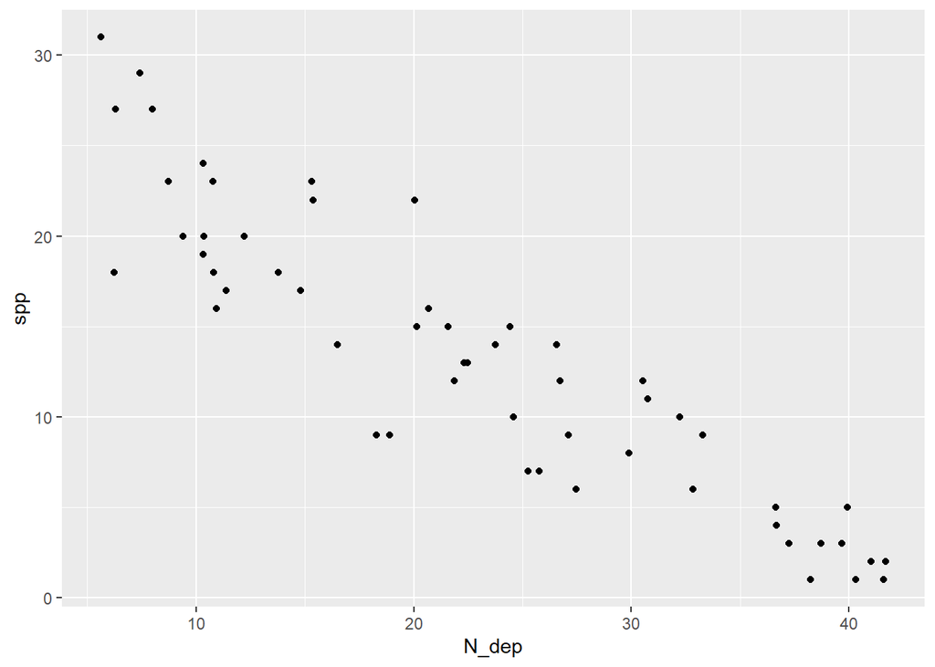

```r
ggplot(spp,
       aes(x = N_dep,
           y = spp)) +
  geom_point()
```

## 1.4 Graded - two regression lines

1.4 Modify your plot to include both a linear regression (in blue), and a Poisson regression (in pink). Also, extend your axes to show where both lines would cross 0 on the y-axis. **NOTE** please make sure that your code chunk does not print out any warnings or messages

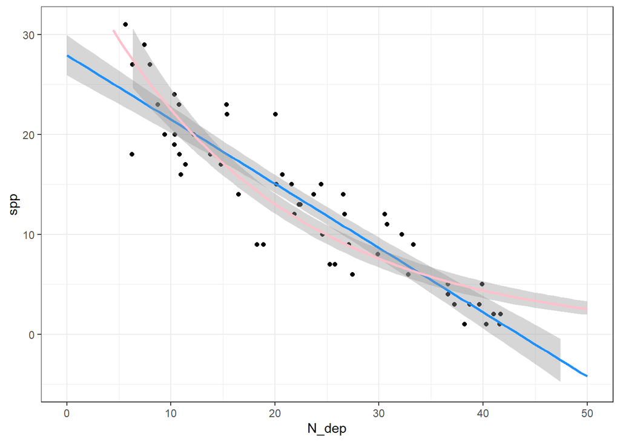

```r
ggplot(spp,
       aes(x = N_dep,
           y = spp)) +
  geom_point() +
  stat_smooth(method = "lm",
              color = "dodgerblue",
              fullrange = TRUE) +
  stat_smooth(method = "glm",
              method.args = list("poisson"),
              fullrange = TRUE,
              color = "pink") +
  scale_x_continuous(limits = c(0, 50)) +
  scale_y_continuous(limits = c(-5, 31)) +
  theme_bw()
```

1.5 Fit a Poisson regression with a log link using the `glm()` function. `spp` is your response variable, and `N_dep` is your predictor variable. Print the summary of your model here as well.

```r
spp_glm <- glm(spp ~ N_dep,
               data = spp,
               family = poisson(link = "log"))
summary(spp_glm)
```

```
Call:
glm(formula = spp ~ N_dep, family = poisson(link = "log"), data = spp)

Coefficients:
             Estimate Std. Error z value Pr(>|z|)
(Intercept)  3.657116   0.075305   48.56   <2e-16 ***
N_dep       -0.054429   0.003888  -14.00   <2e-16 ***
---
Signif. codes:  0 '***' 0.001 '**' 0.01 '*' 0.05 '.' 0.1 ' ' 1

(Dispersion parameter for poisson family taken to be 1)

    Null deviance: 280.031  on 54  degrees of freedom
Residual deviance:  56.174  on 53  degrees of freedom
AIC: 289.97

Number of Fisher Scoring iterations: 4
```

## 1.6 Graded - 1.05, model is good

1.6 What is the ratio of your residual deviance compared with your residual degrees of freedom? Add a code chunk which calculates this ratio, as well as interprets whether or not a Poisson regression is reasonable for this data and explain why or why not.

```r
56/53
```

```
[1] 1.056604
```

```r
# A good ratio is 1, and anything less than 2 is ok
# this ratio is 1.05, indicating that the poisson is a good model
```

1.7 Write out the estimated value for both your intercept and your $\beta_1$ coefficient on **both** the *link* and the *original* scale.

```r
# intercept = 3.65 on the link scale and
exp(3.657116) # on the original scale
```

```
[1] 38.74943
```

```r
# beta_1 = -0.05 on the link and
exp(-0.054429) # on the original scale
```

```
[1] 0.9470257
```

1.8 The $\beta_1$ estimate from the model is on the link-scale. When you back-transform this to the original scale, how can you interpret this number? Or in other words, as `N_dep` increases by 1 unit, what happens to `spp`?

```r
exp(coef(spp_glm)[2])
```

```
    N_dep
0.9470255
```

```r
# this means that for every 1 unit increase in N deposition, the number of species is only ~94.7% of the previous value, or a decline of 5.3%
```

## 1.9 Graded - 22, 13, 8, 4

1.9 Estimate the number of species (on the “real” scale and rounded to the nearest whole number) when `N_dep` = 10, 20, 30 and 40

```r
round(exp(coef(spp_glm)[1] + coef(spp_glm)[2]*c(10, 20, 30, 40)))
```

```
[1] 22 13  8  4
```

1.10 Make a plot of the original data with a Poisson regression. This is similar to 1.4 above, but you will not include the linear regression line nor will you extend the axes.

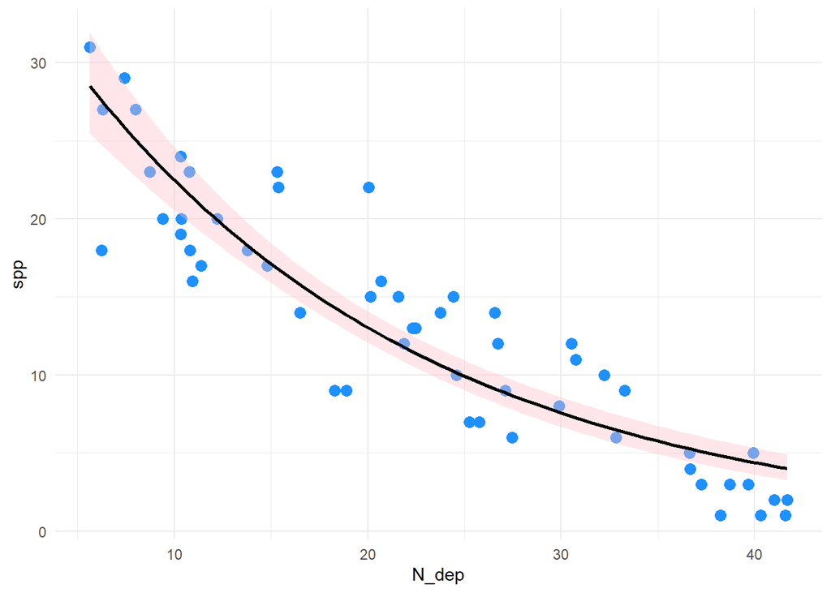

```r
ggplot(spp,
       aes(x = N_dep,
           y = spp)) +
  geom_point(color = "dodgerblue",
             size = 3) +
  stat_smooth(method = "glm",
              method.args = list("poisson"),
              color = "black",
              fill = "pink") +
  theme_minimal()
```

## Problem 2: `case2102` ; Peppered-moth

The peppered moth (*Biston betularia*) is a classic example of biological evolution in response to anthropogenic impacts. A detailed description is available [here](https://branchcollective.org/?ps_articles=nathan-k-hensley-and-john-patrick-james-soot-moth-biston-betularia-and-the-victorian-end-of-nature) (and is also where I got the below images from). Briefly, as the industrial revolution ramped up in England, soot from coal smoke made white barked trees appear black. The peppered moth before this time was white and camouflaged with the tree bark. As the trees became black, a dark “morph” of the peppered moth appeared and became more abundant, presumably because it was better able to hide from predators.

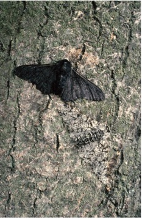

Image showing peppered moths on a light background, which would have been typical pre-industrialization. The light moth is well camouflaged and is likely to avoid predation.

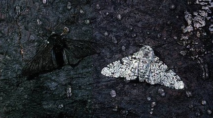

Image of a light and dark morph on a dark background. The light morph stands out and would be easy prey for a predator.

We will be analyzing data collected outside of Liverpool in Northern Wales. Light and dark morphs were glued to trees in life-like positions and then recollected 24 hours later. Missing individuals were assumed to be taken by predators.

We will test the hypothesis that survival depends on the distance from the city (i.e., dark tree bark at low distance, and lighter bark further away) as well as the morph of the individual. This is essentially an ANCOVA design, but the linear model will be switched to a generalized linear model with a binomial response.

### Data loading and wrangling

- Load the `case2102` data and save it as `moth`

```r
data("case2102")
as_tibble(case2102)
```

```
# A tibble: 14 × 4
   Morph Distance Placed Removed
   <fct>    <dbl>  <int>   <int>
 1 light      0       56      17
 2 dark       0       56      14
 3 light      7.2     80      28
 4 dark       7.2     80      20
 5 light     24.1     52      18
 6 dark      24.1     52      22
 7 light     30.2     60       9
 8 dark      30.2     60      16
 9 light     36.4     60      16
10 dark      36.4     60      23
11 light     41.5     84      20
12 dark      41.5     84      40
13 light     51.2     92      24
14 dark      51.2     92      39
```

- `Morph` indicates if the individual was light or dark
- `Distance` is the distance of the plot from Liverpool (km)
- `Placed` is the total number of individuals that were put out into the field
- `Removed` is the number that were missing 24 hours later (i.e., this is the number that “died”). This is what we are classifying as **successes**

### Modify the data

```r
moth <- case2102 |>
  mutate(prop = Removed / Placed,
         Morph = factor(Morph, levels = c("light", "dark")))
as_tibble(moth)
```

```
# A tibble: 14 × 5
   Morph Distance Placed Removed  prop
   <fct>    <dbl>  <int>   <int> <dbl>
 1 light      0       56      17 0.304
 2 dark       0       56      14 0.25
 3 light      7.2     80      28 0.35
 4 dark       7.2     80      20 0.25
 5 light     24.1     52      18 0.346
 6 dark      24.1     52      22 0.423
 7 light     30.2     60       9 0.15
 8 dark      30.2     60      16 0.267
 9 light     36.4     60      16 0.267
10 dark      36.4     60      23 0.383
11 light     41.5     84      20 0.238
12 dark      41.5     84      40 0.476
13 light     51.2     92      24 0.261
14 dark      51.2     92      39 0.424
```

## 2.1 Graded - two regression lines

2.1 Plot the `moth` data with `prop` on the y-axis, `Distance` on the x-axis, and map `Morph` to color. Add a line of best fit based on a binomial glm with `Placed` as the weight in your `stat_smooth()` function

- I recommend playing with the color palette to emphasize the “light” and “dark” morphs

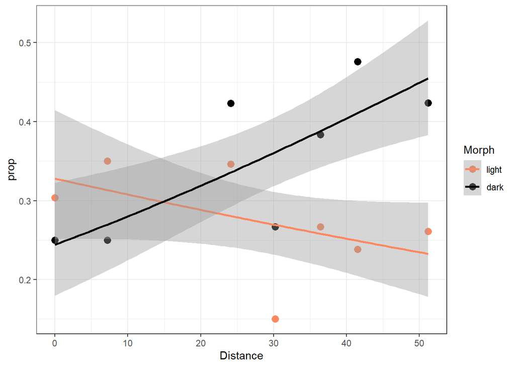

```r
ggplot(moth,
       aes(x = Distance,
           y = prop,
           color = Morph)) +
  geom_point(size = 3) +
  geom_smooth(method = "glm",
              method.args = list(binomial),
              aes(weight = Placed)) +
  theme_bw() +
  scale_color_viridis_d(option = "magma",
                        direction = -1,
                        end = 0.75)
```

2.2 Fit a binomial glm model to the data. The `prop` is going to be your response variable, and `Placed` will be your weight.

- Note that we are testing two main effects as well as the interaction between `Distance` and `Morph`. In the lecture, we only had one continuous predictor

```r
moth_glm <- glm(prop ~ Distance*Morph,
                data = moth,
                family = binomial(link = "logit"),
                weight = Placed)
```